# HW 5 - DW and EDA (project progress 01)

Alexander Burkhart, Marckenrold Cadet

2024-03-29

## Dataset Description

```r
# Load libraries
library(dplyr)
library(readr)
library(tidyr)
library(lubridate)
```

```r
library(ggplot2)
library(stringr)
library(readxl)
library(httr)
```

### Exploration of the Bankruptcies Dataset

```r
# Load dataset
bankruptcies <- read_csv("https://raw.githubusercontent.com/Alexburk93/Data_Wrangling_EDA/main/data/raw_data/Bankruptcies_2011-2020.csv")
```

```
## ──────────────────────────────────────────────────────── Delimiter: "," chr
## (13): COU, Country, VAR, Variable, MEA, Measure, ISIC4...7, ISIC4...8, T... dbl
## (2): PowerCode Code, Value lgl (4): Reference Period Code, Reference Period,
## Flag Codes, Flags
```

```r
# Display structure of dataset
str(bankruptcies)
```

```
## spc_tbl_ [987 × 19] (S3: spec_tbl_df/tbl_df/tbl/data.frame)
##  $ COU                  : chr [1:987] "CAN" "CAN" "CAN" "CAN" ...
##  $ Country              : chr [1:987] "Canada" "Canada" "Canada" "Canada" ...
##  $ VAR                  : chr [1:987] "BANKRUPTCIES" "BANKRUPTCIES" "BANKRUPTCIES" "BANKRUPTCIES" ...
##  $ Variable             : chr [1:987] "Number of bankruptcies" "Number of bankruptcies" "Number of bankruptcies" "Number of bankruptcies" ...
##  $ MEA                  : chr [1:987] "INDEX" "INDEX" "INDEX" "INDEX" ...
##  $ Measure              : chr [1:987] "Index 2007=100" "Index 2007=100" "Index 2007=100" "Index 2007=100" ...
##  $ ISIC4...7            : chr [1:987] "01_99" "01_99" "01_99" "01_99" ...
##  $ ISIC4...8            : chr [1:987] "Grand Total" "Grand Total" "Grand Total" "Grand Total" ...
##  $ TIME                 : chr [1:987] "2011-Q1" "2011-Q2" "2011-Q3" "2011-Q4" ...
##  $ Time                 : chr [1:987] "Q1-2011" "Q2-2011" "Q3-2011" "Q4-2011" ...
##  $ Unit Code            : chr [1:987] "IDX" "IDX" "IDX" "IDX" ...
##  $ Unit                 : chr [1:987] "Index" "Index" "Index" "Index" ...
##  $ PowerCode Code       : num [1:987] 0 0 0 0 0 0 0 0 0 0 ...
##  $ PowerCode            : chr [1:987] "Units" "Units" "Units" "Units" ...
##  $ Reference Period Code: logi [1:987] NA NA NA NA NA NA ...
##  $ Reference Period     : logi [1:987] NA NA NA NA NA NA ...
##  $ Value                : num [1:987] 60 58.3 56.3 55.3 54 ...
##  $ Flag Codes           : logi [1:987] NA NA NA NA NA NA ...
##  $ Flags                : logi [1:987] NA NA NA NA NA NA ...
##  - attr(*, "spec")=
##   .. cols(
##   ..   COU = col_character(),
##   ..   Country = col_character(),
##   ..   VAR = col_character(),
##   ..   Variable = col_character(),
##   ..   MEA = col_character(),
##   ..   Measure = col_character(),
##   ..   ISIC4...7 = col_character(),
##   ..   ISIC4...8 = col_character(),
##   ..   TIME = col_character(),
##   ..   Time = col_character(),
##   ..   `Unit Code` = col_character(),
##   ..   Unit = col_character(),
##   ..   `PowerCode Code` = col_double(),
##   ..   PowerCode = col_character(),
##   ..   `Reference Period Code` = col_logical(),
##   ..   `Reference Period` = col_logical(),
##   ..   Value = col_double(),
##   ..   `Flag Codes` = col_logical(),
##   ..   Flags = col_logical()
##   .. )
##  - attr(*, "problems")=<externalptr>
```

```r
# Show the first few rows
head(bankruptcies)
```

```
## # A tibble: 6 × 19
##   COU   Country VAR       Variable MEA   Measure ISIC4...7 ISIC4...8 TIME  Time
##   <chr> <chr>   <chr>     <chr>    <chr> <chr>   <chr>     <chr>     <chr> <chr>
## 1 CAN   Canada  BANKRUPT… Number … INDEX Index … 01_99     Grand To… 2011… Q1-2…
## 2 CAN   Canada  BANKRUPT… Number … INDEX Index … 01_99     Grand To… 2011… Q2-2…
## 3 CAN   Canada  BANKRUPT… Number … INDEX Index … 01_99     Grand To… 2011… Q3-2…
## 4 CAN   Canada  BANKRUPT… Number … INDEX Index … 01_99     Grand To… 2011… Q4-2…
## 5 CAN   Canada  BANKRUPT… Number … INDEX Index … 01_99     Grand To… 2012… Q1-2…
## 6 CAN   Canada  BANKRUPT… Number … INDEX Index … 01_99     Grand To… 2012… Q2-2…
## # ℹ 9 more variables: `Unit Code` <chr>, Unit <chr>, `PowerCode Code` <dbl>,
## #   PowerCode <chr>, `Reference Period Code` <lgl>, `Reference Period` <lgl>,
## #   Value <dbl>, `Flag Codes` <lgl>, Flags <lgl>
```

```r
# Summary statistics of numerical attributes
summary(bankruptcies)
```

```
##      COU              Country              VAR              Variable
##  Length:987         Length:987         Length:987         Length:987
##  Class :character   Class :character   Class :character   Class :character
##  Mode  :character   Mode  :character   Mode  :character   Mode  :character
##
##
##
##      MEA              Measure           ISIC4...7          ISIC4...8
##  Length:987         Length:987         Length:987         Length:987
##  Class :character   Class :character   Class :character   Class :character
##  Mode  :character   Mode  :character   Mode  :character   Mode  :character
##
##
##
##      TIME               Time            Unit Code             Unit
##  Length:987         Length:987         Length:987         Length:987
##  Class :character   Class :character   Class :character   Class :character
##  Mode  :character   Mode  :character   Mode  :character   Mode  :character
##
##
##
##  PowerCode Code  PowerCode         Reference Period Code Reference Period
##  Min.   :0      Length:987         Mode:logical          Mode:logical
##  1st Qu.:0      Class :character   NA's:987              NA's:987
##  Median :0      Mode  :character
##  Mean   :0
##  3rd Qu.:0
##  Max.   :0
##      Value        Flag Codes      Flags
##  Min.   : 32.09   Mode:logical   Mode:logical
##  1st Qu.: 97.05   NA's:987       NA's:987
##  Median :121.18
##  Mean   :139.36
##  3rd Qu.:146.24
##  Max.   :949.42
```

```r
# Summary statistics of categorical attribute
table(bankruptcies$Country)
```

```
##
##      Australia        Belgium         Brazil         Canada        Denmark
##             41             82             36             40             40
##        Finland         France        Germany        Iceland          Italy
##             80             40             80             40             40
##          Japan    Netherlands    New Zealand         Norway   South Africa
##             40             80             28             80             38
##          Spain         Sweden United Kingdom  United States
##             40             82             40             40
```

```r
# Check for missing values
sum(is.na(bankruptcies))
```

```
## [1] 3948
```

```r
# Removing NA's columns and Time (Duplicate)
data <- select(bankruptcies, -`Flag Codes`, -Flags, -`Reference Period Code`, -`Reference Period`, -TIME)
data %>%
  sample_n(10)
```

```
## # A tibble: 10 × 14
##    COU   Country        VAR     Variable MEA   Measure ISIC4...7 ISIC4...8 Time
##    <chr> <chr>          <chr>   <chr>    <chr> <chr>   <chr>     <chr>     <chr>
##  1 BEL   Belgium        BANKRU… Number … INDEX Index … 01_99C    Grand to… Q3-2…
##  2 GBR   United Kingdom BANKRU… Number … INDEX Index … 01_99C    Grand to… Q4-2…
##  3 GBR   United Kingdom BANKRU… Number … INDEX Index … 01_99C    Grand to… Q4-2…
##  4 AUS   Australia      BANKRU… Number … INDEX Index … 01_99C    Grand to… Q2-2…
##  5 BEL   Belgium        BANKRU… Number … INDEX Index … 01_99C    Grand to… Q2-2…
##  6 FIN   Finland        BANKRU… Number … INDEX Index … 01_99C    Grand to… Q4-2…
##  7 DNK   Denmark        BANKRU… Number … INDEX Index … 01_99     Grand To… Q3-2…
##  8 BEL   Belgium        BANKRU… Number … INDEX Index … 01_99     Grand To… Q2-2…
##  9 ITA   Italy          BANKRU… Number … INDEX Index … 01_99     Grand To… Q3-2…
## 10 AUS   Australia      BANKRU… Number … INDEX Index … 01_99C    Grand to… Q3-2…
## # ℹ 5 more variables: `Unit Code` <chr>, Unit <chr>, `PowerCode Code` <dbl>,
## #   PowerCode <chr>, Value <dbl>
```

```r
# Display the structure of the modified dataset
str(data)
```

```
## tibble [987 × 14] (S3: tbl_df/tbl/data.frame)
##  $ COU           : chr [1:987] "CAN" "CAN" "CAN" "CAN" ...
##  $ Country       : chr [1:987] "Canada" "Canada" "Canada" "Canada" ...
##  $ VAR           : chr [1:987] "BANKRUPTCIES" "BANKRUPTCIES" "BANKRUPTCIES" "BANKRUPTCIES" ...
##  $ Variable      : chr [1:987] "Number of bankruptcies" "Number of bankruptcies" "Number of bankruptcies" "Number of bankruptcies" ...
##  $ MEA           : chr [1:987] "INDEX" "INDEX" "INDEX" "INDEX" ...
##  $ Measure       : chr [1:987] "Index 2007=100" "Index 2007=100" "Index 2007=100" "Index 2007=100" ...
##  $ ISIC4...7     : chr [1:987] "01_99" "01_99" "01_99" "01_99" ...
##  $ ISIC4...8     : chr [1:987] "Grand Total" "Grand Total" "Grand Total" "Grand Total" ...
##  $ Time          : chr [1:987] "Q1-2011" "Q2-2011" "Q3-2011" "Q4-2011" ...
##  $ Unit Code     : chr [1:987] "IDX" "IDX" "IDX" "IDX" ...
##  $ Unit          : chr [1:987] "Index" "Index" "Index" "Index" ...
##  $ PowerCode Code: num [1:987] 0 0 0 0 0 0 0 0 0 0 ...
##  $ PowerCode     : chr [1:987] "Units" "Units" "Units" "Units" ...
##  $ Value         : num [1:987] 60 58.3 56.3 55.3 54 ...
```

```r
# Check the dimension of data
dim(data)
```

```
## [1] 987  14
```

For this project, we are only focusing on information from 2011 to 2020. And to minimize the workload, we are analyzing 19 countries.

```r
# Create new columns 'Quarter' and 'Year' from 'Time'
new_data <- mutate(data,
                   Quarter = str_sub(Time, 1, 2), # Extract Quarter
                   Year = as.numeric(str_sub(Time, 4))) # Extract Year and convert to numeric

# remove the original 'Time' column
new_data <- select(new_data, -Time)
new_data
```

```
## # A tibble: 987 × 15
##    COU   Country VAR      Variable MEA   Measure ISIC4...7 ISIC4...8 `Unit Code`
##    <chr> <chr>   <chr>    <chr>    <chr> <chr>   <chr>     <chr>     <chr>
##  1 CAN   Canada  BANKRUP… Number … INDEX Index … 01_99     Grand To… IDX
##  2 CAN   Canada  BANKRUP… Number … INDEX Index … 01_99     Grand To… IDX
##  3 CAN   Canada  BANKRUP… Number … INDEX Index … 01_99     Grand To… IDX
##  4 CAN   Canada  BANKRUP… Number … INDEX Index … 01_99     Grand To… IDX
##  5 CAN   Canada  BANKRUP… Number … INDEX Index … 01_99     Grand To… IDX
##  6 CAN   Canada  BANKRUP… Number … INDEX Index … 01_99     Grand To… IDX
##  7 CAN   Canada  BANKRUP… Number … INDEX Index … 01_99     Grand To… IDX
##  8 CAN   Canada  BANKRUP… Number … INDEX Index … 01_99     Grand To… IDX
##  9 CAN   Canada  BANKRUP… Number … INDEX Index … 01_99     Grand To… IDX
## 10 CAN   Canada  BANKRUP… Number … INDEX Index … 01_99     Grand To… IDX
## # ℹ 977 more rows
## # ℹ 6 more variables: Unit <chr>, `PowerCode Code` <dbl>, PowerCode <chr>,
## #   Value <dbl>, Quarter <chr>, Year <dbl>
```

```r
# Get date range
date_range <- range(new_data$Year)

# Count unique countries
n_countries <- length(unique(new_data$Country))

# Print the results
n_countries
```

```
## [1] 19
```

```r
date_range
```

```
## [1] 2011 2021
```

```r
# Only need data from 2011-2020, excluding 2021
bankruptcy_data <- filter(new_data, Year != 2021)
new_data
```

```
## # A tibble: 987 × 15
##    COU   Country VAR      Variable MEA   Measure ISIC4...7 ISIC4...8 `Unit Code`
##    <chr> <chr>   <chr>    <chr>    <chr> <chr>   <chr>     <chr>     <chr>
##  1 CAN   Canada  BANKRUP… Number … INDEX Index … 01_99     Grand To… IDX
##  2 CAN   Canada  BANKRUP… Number … INDEX Index … 01_99     Grand To… IDX
##  3 CAN   Canada  BANKRUP… Number … INDEX Index … 01_99     Grand To… IDX
##  4 CAN   Canada  BANKRUP… Number … INDEX Index … 01_99     Grand To… IDX
##  5 CAN   Canada  BANKRUP… Number … INDEX Index … 01_99     Grand To… IDX
##  6 CAN   Canada  BANKRUP… Number … INDEX Index … 01_99     Grand To… IDX
##  7 CAN   Canada  BANKRUP… Number … INDEX Index … 01_99     Grand To… IDX
##  8 CAN   Canada  BANKRUP… Number … INDEX Index … 01_99     Grand To… IDX
##  9 CAN   Canada  BANKRUP… Number … INDEX Index … 01_99     Grand To… IDX
## 10 CAN   Canada  BANKRUP… Number … INDEX Index … 01_99     Grand To… IDX
## # ℹ 977 more rows
## # ℹ 6 more variables: Unit <chr>, `PowerCode Code` <dbl>, PowerCode <chr>,
## #   Value <dbl>, Quarter <chr>, Year <dbl>
```

```r
# Get date range of new updated dataset
date_range <- range(bankruptcy_data$Year)

# Extract start and end years from the range
start_year <- date_range[1]
end_year <- date_range[2]

# Count unique countries
n_countries <- length(unique(bankruptcy_data$Country))

# Print the results
cat("Number of country: ", n_countries, "\n")
```

```
## Number of country:  19
```

```r
cat("Date range from: ", start_year, " to ", end_year, "\n")
```

```
## Date range from:  2011  to  2020
```

### Exploring GDP dataset & analyze foundings

```r
# Load dataset
my_data <- read_csv("https://raw.githubusercontent.com/Alexburk93/Data_Wrangling_EDA/main/data/raw_data/GDP_Data/GPD_1960_2022.csv")
my_data
```

```
## # A tibble: 266 × 67
##    `Country Name`      `Country Code` `Indicator Name` `Indicator Code`   `1960`
##    <chr>               <chr>          <chr>            <chr>               <dbl>
##  1 Aruba               ABW            GDP (current US… NY.GDP.MKTP.CD   NA
##  2 Africa Eastern and… AFE            GDP (current US… NY.GDP.MKTP.CD    1.85e10
##  3 Afghanistan         AFG            GDP (current US… NY.GDP.MKTP.CD    5.38e 8
##  4 Africa Western and… AFW            GDP (current US… NY.GDP.MKTP.CD    1.04e10
##  5 Angola              AGO            GDP (current US… NY.GDP.MKTP.CD   NA
##  6 Albania             ALB            GDP (current US… NY.GDP.MKTP.CD   NA
##  7 Andorra             AND            GDP (current US… NY.GDP.MKTP.CD   NA
##  8 Arab World          ARB            GDP (current US… NY.GDP.MKTP.CD   NA
##  9 United Arab Emirat… ARE            GDP (current US… NY.GDP.MKTP.CD   NA
## 10 Argentina           ARG            GDP (current US… NY.GDP.MKTP.CD   NA
## # ℹ 256 more rows
## # ℹ 62 more variables: `1961` <dbl>, `1962` <dbl>, `1963` <dbl>, `1964` <dbl>,
## #   `1965` <dbl>, `1966` <dbl>, `1967` <dbl>, `1968` <dbl>, `1969` <dbl>,
## #   `1970` <dbl>, `1971` <dbl>, `1972` <dbl>, `1973` <dbl>, `1974` <dbl>,
## #   `1975` <dbl>, `1976` <dbl>, `1977` <dbl>, `1978` <dbl>, `1979` <dbl>,
## #   `1980` <dbl>, `1981` <dbl>, `1982` <dbl>, `1983` <dbl>, `1984` <dbl>,
## #   `1985` <dbl>, `1986` <dbl>, `1987` <dbl>, `1988` <dbl>, `1989` <dbl>, …
```

The Years are in the header, using `pivot_longer()` to convert into two column Year and GDP

```r
# Pivot the data from wide to long format
joy <- pivot_longer(my_data,
                         cols = -c(`Country Name`, `Country Code`, `Indicator Name`, `Indicator Code`),
                         names_to = "Year",
                         values_to = "GDP")

# Show the first few rows
head(joy)
```

```
## # A tibble: 6 × 6
##   `Country Name` `Country Code` `Indicator Name`  `Indicator Code` Year    GDP
##   <chr>          <chr>          <chr>             <chr>            <chr> <dbl>
## 1 Aruba          ABW            GDP (current US$) NY.GDP.MKTP.CD   1960     NA
## 2 Aruba          ABW            GDP (current US$) NY.GDP.MKTP.CD   1961     NA
## 3 Aruba          ABW            GDP (current US$) NY.GDP.MKTP.CD   1962     NA
## 4 Aruba          ABW            GDP (current US$) NY.GDP.MKTP.CD   1963     NA
## 5 Aruba          ABW            GDP (current US$) NY.GDP.MKTP.CD   1964     NA
## 6 Aruba          ABW            GDP (current US$) NY.GDP.MKTP.CD   1965     NA
```

Perfom `summary stastics`, check for `NA's`, dimension `dim()`, etc.

```r
# Display structure of dataset
str(joy)
```

```
## tibble [16,758 × 6] (S3: tbl_df/tbl/data.frame)
##  $ Country Name  : chr [1:16758] "Aruba" "Aruba" "Aruba" "Aruba" ...
##  $ Country Code  : chr [1:16758] "ABW" "ABW" "ABW" "ABW" ...
##  $ Indicator Name: chr [1:16758] "GDP (current US$)" "GDP (current US$)" "GDP (current US$)" "GDP (current US$)" ...
##  $ Indicator Code: chr [1:16758] "NY.GDP.MKTP.CD" "NY.GDP.MKTP.CD" "NY.GDP.MKTP.CD" "NY.GDP.MKTP.CD" ...
##  $ Year          : chr [1:16758] "1960" "1961" "1962" "1963" ...
##  $ GDP           : num [1:16758] NA NA NA NA NA NA NA NA NA NA ...
```

```r
# Show the first few rows
head(joy)
```

```
## # A tibble: 6 × 6
##   `Country Name` `Country Code` `Indicator Name`  `Indicator Code` Year    GDP
##   <chr>          <chr>          <chr>             <chr>            <chr> <dbl>
## 1 Aruba          ABW            GDP (current US$) NY.GDP.MKTP.CD   1960     NA
## 2 Aruba          ABW            GDP (current US$) NY.GDP.MKTP.CD   1961     NA
## 3 Aruba          ABW            GDP (current US$) NY.GDP.MKTP.CD   1962     NA
## 4 Aruba          ABW            GDP (current US$) NY.GDP.MKTP.CD   1963     NA
## 5 Aruba          ABW            GDP (current US$) NY.GDP.MKTP.CD   1964     NA
## 6 Aruba          ABW            GDP (current US$) NY.GDP.MKTP.CD   1965     NA
```

```r
# Summary statistics of numerical attributes
summary(joy)
```

```
##  Country Name       Country Code       Indicator Name     Indicator Code
##  Length:16758       Length:16758       Length:16758       Length:16758
##  Class :character   Class :character   Class :character   Class :character
##  Mode  :character   Mode  :character   Mode  :character   Mode  :character
##
##
##
##
##      Year                GDP
##  Length:16758       Min.   :8.825e+06
##  Class :character   1st Qu.:2.435e+09
##  Mode  :character   Median :1.786e+10
##                     Mean   :1.224e+12
##                     3rd Qu.:2.264e+11
##                     Max.   :1.009e+14
##                     NA's   :3560
```

```r
# Summary statistics of categorical attribute
table(joy$`Indicator Code`)
```

```
##
## NY.GDP.MKTP.CD
##          16758
```

```r
# Check for missing values
sum(is.na(joy))
```

```
## [1] 3560
```

```r
# Check the dimension of data
dim(joy)
```

```
## [1] 16758     6
```

Filter the data to only show the 19 countries and the date range the project is focused on.

```r
# Define the list of 19 countries
countries_of_interest <- c("Australia", "Belgium", "Brazil", "Canada", "Denmark",
                           "Finland", "France", "Germany", "Iceland", "Italy",
                           "Japan", "Netherlands", "New Zealand", "Norway",
                           "South Africa", "Spain", "Sweden", "United Kingdom",
                           "United States")

# Filter the data for the 19 countries
gdp <- joy %>%
  filter(`Country Name` %in% countries_of_interest)

# Define the date range of focus
start_year <- 2011
end_year <- 2020

# Filter the data for the date range
gdp <- gdp %>%
  filter(as.numeric(Year) >= start_year & as.numeric(Year) <= end_year)

# Show the filtered data
gdp %>%
  sample_n(10)
```

```
## # A tibble: 10 × 6
##    `Country Name` `Country Code` `Indicator Name` `Indicator Code` Year      GDP
##    <chr>          <chr>          <chr>            <chr>            <chr>   <dbl>
##  1 Brazil         BRA            GDP (current US… NY.GDP.MKTP.CD   2018  1.92e12
##  2 New Zealand    NZL            GDP (current US… NY.GDP.MKTP.CD   2015  1.78e11
##  3 Japan          JPN            GDP (current US… NY.GDP.MKTP.CD   2012  6.27e12
##  4 South Africa   ZAF            GDP (current US… NY.GDP.MKTP.CD   2015  3.47e11
##  5 Australia      AUS            GDP (current US… NY.GDP.MKTP.CD   2013  1.58e12
##  6 Finland        FIN            GDP (current US… NY.GDP.MKTP.CD   2019  2.69e11
##  7 United Kingdom GBR            GDP (current US… NY.GDP.MKTP.CD   2013  2.78e12
##  8 Spain          ESP            GDP (current US… NY.GDP.MKTP.CD   2018  1.42e12
##  9 South Africa   ZAF            GDP (current US… NY.GDP.MKTP.CD   2018  4.05e11
## 10 Netherlands    NLD            GDP (current US… NY.GDP.MKTP.CD   2018  9.14e11
```

```r
# Display structure of dataset
str(gdp)
```

```
## tibble [190 × 6] (S3: tbl_df/tbl/data.frame)
##  $ Country Name  : chr [1:190] "Australia" "Australia" "Australia" "Australia" ...
##  $ Country Code  : chr [1:190] "AUS" "AUS" "AUS" "AUS" ...
##  $ Indicator Name: chr [1:190] "GDP (current US$)" "GDP (current US$)" "GDP (current US$)" "GDP (current US$)" ...
##  $ Indicator Code: chr [1:190] "NY.GDP.MKTP.CD" "NY.GDP.MKTP.CD" "NY.GDP.MKTP.CD" "NY.GDP.MKTP.CD" ...
##  $ Year          : chr [1:190] "2011" "2012" "2013" "2014" ...
##  $ GDP           : num [1:190] 1.40e+12 1.55e+12 1.58e+12 1.47e+12 1.35e+12 ...
```

```r
# Convert Year to numeric
# gdp$Year <- as.numeric(gdp$Year)

# Show the first few rows
head(gdp)
```

```
## # A tibble: 6 × 6
##   `Country Name` `Country Code` `Indicator Name`  `Indicator Code` Year      GDP
##   <chr>          <chr>          <chr>             <chr>            <chr>   <dbl>
## 1 Australia      AUS            GDP (current US$) NY.GDP.MKTP.CD   2011  1.40e12
## 2 Australia      AUS            GDP (current US$) NY.GDP.MKTP.CD   2012  1.55e12
## 3 Australia      AUS            GDP (current US$) NY.GDP.MKTP.CD   2013  1.58e12
## 4 Australia      AUS            GDP (current US$) NY.GDP.MKTP.CD   2014  1.47e12
## 5 Australia      AUS            GDP (current US$) NY.GDP.MKTP.CD   2015  1.35e12
## 6 Australia      AUS            GDP (current US$) NY.GDP.MKTP.CD   2016  1.21e12
```

```r
# Summary statistics of numerical attributes
summary(gdp)
```

```
##  Country Name       Country Code       Indicator Name     Indicator Code
##  Length:190         Length:190         Length:190         Length:190
##  Class :character   Class :character   Class :character   Class :character
##  Mode  :character   Mode  :character   Mode  :character   Mode  :character
##
##
##
##      Year                GDP
##  Length:190         Min.   :1.475e+10
##  Class :character   1st Qu.:3.885e+11
##  Mode  :character   Median :1.319e+12
##                     Mean   :2.375e+12
##                     3rd Qu.:2.611e+12
##                     Max.   :2.138e+13
```

```r
# Summary statistics of categorical attribute
table(gdp$`Indicator Code`)
```

```
##
## NY.GDP.MKTP.CD
##            190
```

```r
# Check for missing values
sum(is.na(gdp))
```

```
## [1] 0
```

```r
# Check the dimension of data
dim(gdp)
```

```
## [1] 190   6
```

```r
# Group the filtered data by Year and calculate the mean GDP for each year
mean_gdp_by_year <- gdp %>%
  group_by(Year) %>%
  summarize(mean_GDP = mean(GDP, na.rm = TRUE))

# Show the mean GDP for each year
print(mean_gdp_by_year)
```

```
## # A tibble: 10 × 2
##    Year  mean_GDP
##    <chr>    <dbl>
##  1 2011   2.34e12
##  2 2012   2.33e12
##  3 2013   2.34e12
##  4 2014   2.38e12
##  5 2015   2.23e12
##  6 2016   2.27e12
##  7 2017   2.38e12
##  8 2018   2.50e12
##  9 2019   2.53e12
## 10 2020   2.45e12
```

Visualization for top 10 highest GDP by Counries Over Time.

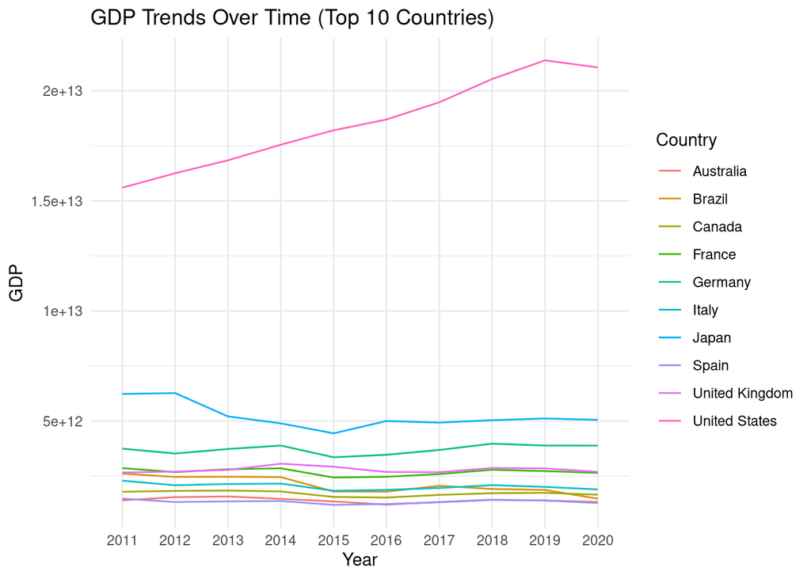

```r
# Filter to include only the top 10 countries with the highest GDP values
top_10_gdp <- gdp %>%
  group_by(`Country Name`) %>%
  summarize(total_gdp = sum(GDP, na.rm = TRUE)) %>%
  top_n(10, total_gdp) %>%
  left_join(gdp, by = "Country Name")

# Convert GDP values to millions or billions
top_10_gdp <- top_10_gdp %>%
  mutate(GDP_formatted = case_when(
    GDP >= 1e12 ~ paste0(round(GDP / 1e12, 1), "T"),  # Convert to trillions
    GDP >= 1e9 ~ paste0(round(GDP / 1e9, 1), "B"),  # Convert to billions
    GDP >= 1e6 ~ paste0(round(GDP / 1e6, 1), "M"),   # Convert to millions
    TRUE ~ as.character(GDP)                        # Keep unchanged if less than 1 million
  ))

# Create a line plot of GDP over time with formatted values for the top 10 countries
ggplot(top_10_gdp, aes(x = Year, y = GDP, group = `Country Name`)) +
  geom_line(aes(color = `Country Name`)) +
  labs(title = "GDP Trends Over Time (Top 10 Countries)",
       x = "Year",
       y = "GDP",
       color = "Country") +
  scale_y_continuous(labels = function(x) paste0(x, "")) +  # Ensure y-axis labels are character type
  theme_minimal()
```

### Exploration of the Suicide Rate Dataset

```r
# Load data set from github
suicide_df = read_csv("https://raw.githubusercontent.com/Alexburk93/Data_Wrangling_EDA/main/data/raw_data/death-rate-from-suicides-gho%20new.csv")
suicide_df$`Age-standardized suicide rate - Sex: both sexes` = as.double(suicide_df$`Age-standardized suicide rate - Sex: both sexes`)
summary(suicide_df)
```

```
##     Entity              Code                Year
##  Length:3876        Length:3876        Min.   :2000
##  Class :character   Class :character   1st Qu.:2004
##  Mode  :character   Mode  :character   Median :2009
##                                        Mean   :2009
##                                        3rd Qu.:2014
##                                        Max.   :2019
##
##  Age-standardized suicide rate - Sex: both sexes
##  Min.   :  0.000
##  1st Qu.:  5.955
##  Median : 10.015
##  Mean   : 68.421
##  3rd Qu.:141.230
##  Max.   :962.889
##  NA's   :5
```

```r
# Consider removing Lesotho from the analysis
suicide_df %>%
  filter(is.na(`Age-standardized suicide rate - Sex: both sexes`))
```

```
## # A tibble: 5 × 4
##   Entity  Code   Year `Age-standardized suicide rate - Sex: both sexes`
##   <chr>   <chr> <dbl>                                             <dbl>
## 1 Lesotho LSO    2012                                                NA
## 2 Lesotho LSO    2013                                                NA
## 3 Lesotho LSO    2014                                                NA
## 4 Lesotho LSO    2015                                                NA
## 5 Lesotho LSO    2016                                                NA
```

```r
# Remove the Region / Income classes and Lesotho
suicide_df_countries = suicide_df %>%
  filter(Code != "0", Code != "LSO")
```

```r
avg_country = suicide_df_countries %>%
  group_by(Entity) %>%
  summarise(avg_per_country = mean(`Age-standardized suicide rate - Sex: both sexes`)) %>%
  arrange(desc(avg_per_country))
```

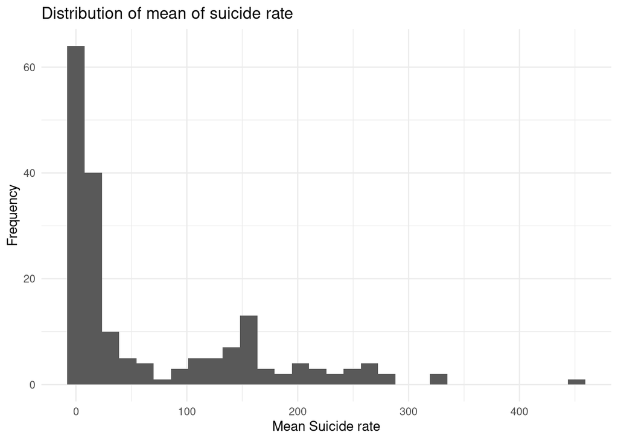

```r
ggplot(avg_country, aes(x = avg_per_country)) +
  geom_histogram() +
  labs(x = "Mean Suicide rate", y = "Frequency", title = "Distribution of mean of suicide rate") +
  theme_minimal()
```

### Exploration of the Happiness Dataset

```r
# Use the raw file URL
url <- "https://github.com/Alexburk93/Data_Wrangling_EDA/raw/main/data/raw_data/WHR20_DataForTable2.1.xls"
response <- GET(url)
content <- content(response, "raw")
temp <- tempfile(fileext = ".xls")
writeBin(content, temp)
happiness_df <- read_excel(temp)

# View the data
head(happiness_df)
```

```
## # A tibble: 6 × 26
##   `Country name`  year `Life Ladder` `Log GDP per capita` `Social support`
##   <chr>          <dbl>         <dbl>                <dbl>            <dbl>
## 1 Afghanistan     2008          3.72                 7.14            0.451
## 2 Afghanistan     2009          4.40                 7.31            0.552
## 3 Afghanistan     2010          4.76                 7.42            0.539
## 4 Afghanistan     2011          3.83                 7.39            0.521
## 5 Afghanistan     2012          3.78                 7.48            0.521
## 6 Afghanistan     2013          3.57                 7.50            0.484
## # ℹ 21 more variables: `Healthy life expectancy at birth` <dbl>,
## #   `Freedom to make life choices` <dbl>, Generosity <dbl>,
## #   `Perceptions of corruption` <dbl>, `Positive affect` <dbl>,
## #   `Negative affect` <dbl>, `Confidence in national government` <dbl>,
## #   `Democratic Quality` <dbl>, `Delivery Quality` <dbl>,
## #   `Standard deviation of ladder by country-year` <dbl>,
## #   `Standard deviation/Mean of ladder by country-year` <dbl>, …
```

```r
# create data frame with selected columns. Based on the description of the different variables.
happiness_df_filtered = happiness_df %>%
  select(`Country name`, `year` , `Life Ladder`, `Social support`, `Healthy life expectancy at birth`, `Freedom to make life choices`, `Perceptions of corruption`)

summary(happiness_df_filtered)
```

```
##  Country name            year       Life Ladder    Social support
##  Length:1848        Min.   :2005   Min.   :2.375   Min.   :0.2902
##  Class :character   1st Qu.:2010   1st Qu.:4.623   1st Qu.:0.7483
##  Mode  :character   Median :2013   Median :5.363   Median :0.8340
##                     Mean   :2013   Mean   :5.446   Mean   :0.8111
##                     3rd Qu.:2016   3rd Qu.:6.268   3rd Qu.:0.9046
##                     Max.   :2019   Max.   :8.019   Max.   :0.9873
##                                                    NA's   :13
##  Healthy life expectancy at birth Freedom to make life choices
##  Min.   :32.30                    Min.   :0.2575
##  1st Qu.:58.30                    1st Qu.:0.6431
##  Median :65.10                    Median :0.7575
##  Mean   :63.17                    Mean   :0.7385
##  3rd Qu.:68.39                    3rd Qu.:0.8524
##  Max.   :77.10                    Max.   :0.9852
##  NA's   :52                       NA's   :31
##  Perceptions of corruption
##  Min.   :0.0352
##  1st Qu.:0.6927
##  Median :0.8036
##  Mean   :0.7491
##  3rd Qu.:0.8737
##  Max.   :0.9833
##  NA's   :103
```

```r
avg_happiness_per_country = happiness_df_filtered %>%
  group_by(`Country name`) %>%
  summarise(avg_happiness = mean(`Life Ladder`)) %>%
  arrange(desc(avg_happiness))
```

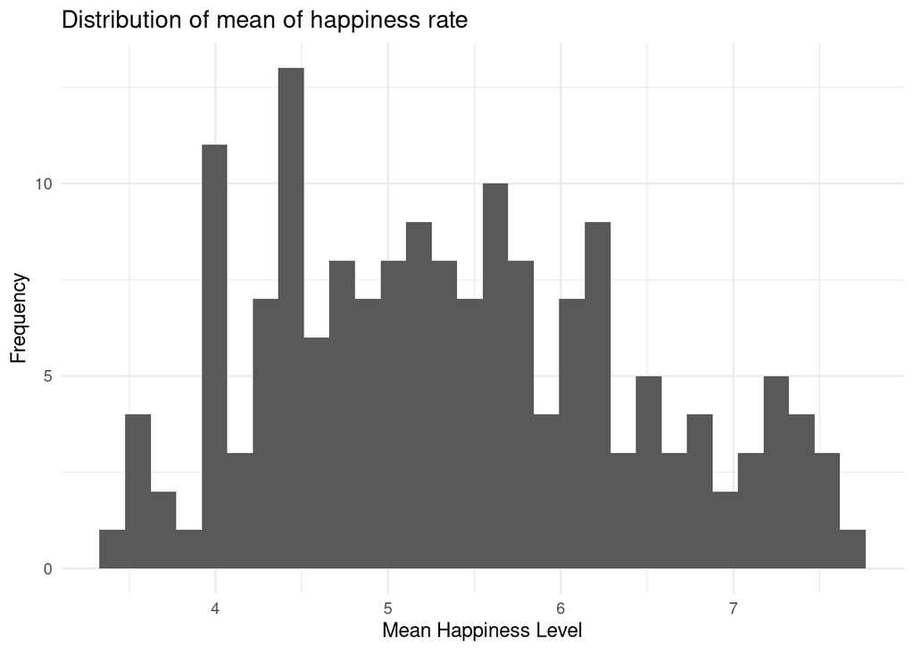

```r
ggplot(avg_happiness_per_country, aes(x = avg_happiness)) +
  geom_histogram() +
  labs(x = "Mean Happiness Level", y = "Frequency", title = "Distribution of mean of happiness rate") +
  theme_minimal()
```

## References

**Title**: A Study for Effects of Economic Growth Rate and Unemployment Rate to Suicide Rate in Korea. **Author**: Jong Soon Park, June Young Lee, Soon Duck Kim

“**Objectives**: We investigated the effects of the economic growth and unemployment rates on the suicide rate in Korea, between 1983 and 2000, using a time-series regression model. The purpose of this study was to model and test the magnitude of the rate of suicide, with the Korean unemployment rate and GDP.” [1] “**Conclusion**: It was found that the suicide rate was closely related to the National’s economic status of Korea, which is similar to the results found in studies in other countries. We expected, therefore, that this study could be used as the basis for further suicide-related studies.” [1]

**Title**: Ten-year evolution of suicide rates and economic indicators in large Brazilian urban centers **Author**: Asevedo, Elson; Ziebold, Carolina; Diniz, Elton; Gadelha, Ary; Mari, Jair

“**Purpose of review**: This was a retrospective ecological study to examine the relationship between suicide rates and economic indicators in large Brazilian urban centers. Data on macroeconomic indicators (GDP and unemployment rates) and suicide rates of the largest Brazilian cities were collected from January 2006 to December 2015.”[2]

“**Summary** The effect of economic indicators was heterogeneous among the centers, but, overall, the variation in suicide rates was inversely related to unemployment and did not show a significant relationship with GDP. These findings indicate a more complex link between economics and suicide whenever looking at local regional indicators. Further research should focus on possible intervening factors, what may inform better preventive interventions” [2]

**Title**: The association between nation-level social and economic indices and suicide rates: A pilot study **Author**: Ravi Philip Rajkumar

**Introduction** “Suicide is one of the leading causes of premature mortality worldwide. An analysis of global suicide data for the period 1990–2016, covering 195 countries, found that suicide was among the ten leading causes of years of life lost in Europe, the Americas and the Asia-Pacific region (Naghavi, 2019). Because of this, suicide prevention has been accorded one of the highest priorities in national and international public health plans, such as the World Health Organization’s Comprehensive Mental Health Action Plan (World Health Organization, 2021a). The act of suicide is a complex behavior which results from the interaction between an innate diathesis and external stressors (van Heeringen, 2012).” [3]

**Conclusions** “Social factors are important determinants of suicide. Despite certain limitations, the results of the current study suggest that sustainable development may play a role in the mitigation of suicide risk, Economic inequality may contribute to variations in suicide risk, particularly in men. Moreover, the strength and direction of the associations between socioeconomic factors and suicide varies across income groups, highlighting the need for an in-depth understanding of each country’s social, cultural and economic profile when planning large-scale social interventions aimed at suicide prevention.” [3]

**Title**:Is Happiness the main cause fro the rising suicide rate in the world? **Author**: BONG JIN HAW, CHONG YOCK LOON, TAI HONG TING, TEOH KAH CHUN, WONG CHIN HING

**Introduction** “This study investigates the impact of happiness on suicide rate. Beside theimpact of happiness, employment, gross domestic product, education, health expenditure and population on the suicide rate is also studied. The study divides the data into three sets including 31 developed and developing countries, 26 developed countries, and 5 developing countries. A significant relationship between happiness and the suicide rate is found in developing countries.” [4]

**Conclusions** “Surprisingly, based on the result it can be concluded that the happiness in developing countries will significantly impact and influence the suicide rate indeed. It is important to realize that the happiness is negatively affect the suicide rate in developing countries which means that increase in the happiness will subsequently lower down the suicide rate. Moreover, other economic factors such as employment, gross domestic product, government health expenditure, education and population are also included in this study to carry out their impact towards the suicide rate.” [4]

[1] https://www.jpmph.org/journal/view.php?number=50 (visited 03/24/2024) [2] https://journals.lww.com/co-psychiatry/abstract/2018/05000/ten_year_evolution_of_suicide_rates_and_economic.15.aspx (visited 03/22/2024) [3] https://www.frontiersin.org/articles/10.3389/fsoc.2023.1123284/full [4] http://eprints.utar.edu.my/2869/1/fyp_BF_2018_BJH_-_1403312.pdf